# Australia CO2 emission

Aphiaut Imuan

2023-06-27

# Data Description

Energy data from [Department of Climate Change, Energy, the Environment and Water](https://www.energy.gov.au/publications/australian-energy-update-2021)

Population data from [World Bank database](https://data.worldbank.org/indicator/SP.POP.TOTL?locations=AU)

Net migration data from [World Bank database](https://data.worldbank.org/indicator/SM.POP.NETM?locations=AU)

GDP per capita constant 2015$ US [World Bank database](https://data.worldbank.org/indicator/NY.GDP.MKTP.KD?locations=AU)

# Theory for this report

IPAT theory or The Environmental Impacts (I) on Population (P), Affluence (A), and Technology (T) EKC theory or the environmental Kuznets curve created by Simon Smith Kuznets

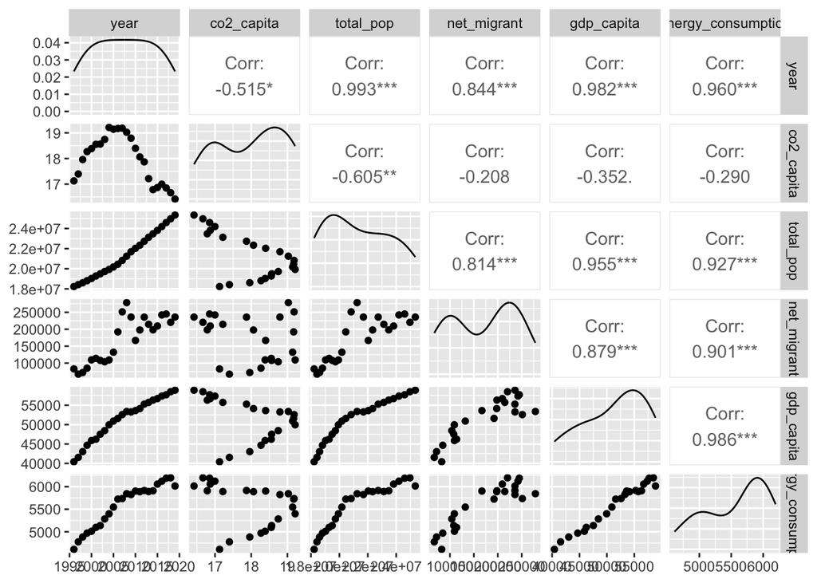

From the figure illustrates correlations between CO2 and predictors are not linear relationship, therefore all predictors need to transform. In this transformation based on the Stochastic Regression on Population, Affluence and Technology (STIRPAT) framework because the IPAT model is theory that not useful for statistic. However, this framework has a drawback that the correlation between response variable and predictors are linear relationship.

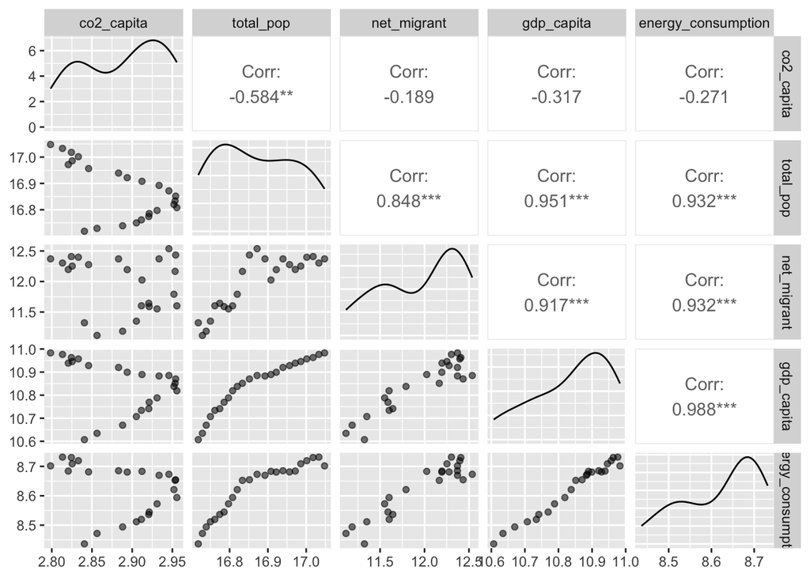

```
##
## Call:
## lm(formula = co2_capita ~ total_pop + net_migrant + gdp_capita +
##     energy_consumption + total_pop:net_migrant + total_pop:gdp_capita +
##     total_pop:energy_consumption, data = co2_trans)
##
## Residuals:
##        Min         1Q     Median         3Q        Max
## -0.0257676 -0.0032623 -0.0001189  0.0064135  0.0184493
##
## Coefficients:
##                               Estimate Std. Error t value Pr(>|t|)
## (Intercept)                  -103.2968   209.7419  -0.492    0.629
## total_pop                       5.6407    12.6089   0.447    0.661
## net_migrant                    -2.8781     4.6530  -0.619    0.545
## gdp_capita                     10.1110    30.6447   0.330    0.746
## energy_consumption              6.2250    33.4043   0.186    0.855
## total_pop:net_migrant           0.1714     0.2764   0.620    0.544
## total_pop:gdp_capita           -0.5600     1.8195  -0.308    0.762
## total_pop:energy_consumption   -0.3438     1.9773  -0.174    0.864
##
## Residual standard error: 0.01261 on 16 degrees of freedom
## Multiple R-squared:  0.9592, Adjusted R-squared:  0.9414
## F-statistic: 53.74 on 7 and 16 DF,  p-value: 6.213e-10
```

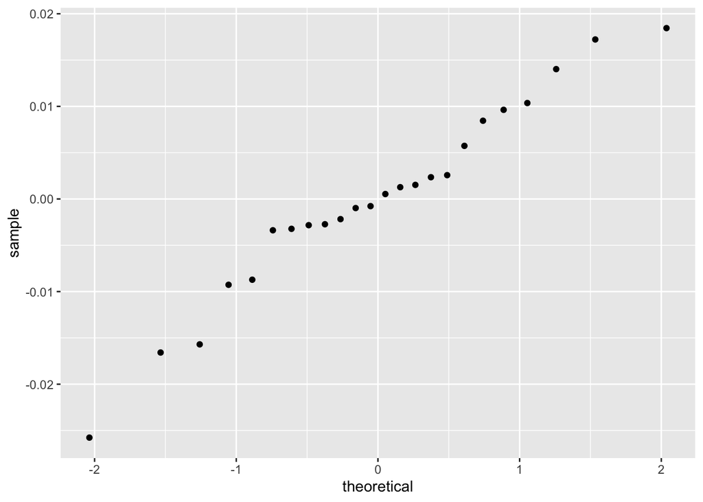

All p-value of predictors are not significant. It means they do not have enough evidence to conclude that predictors affect to CO2 emission per capita in Australia. Moreover, this QQ-plot shows outliers from both tails, and a close alignment of points is not linear line.

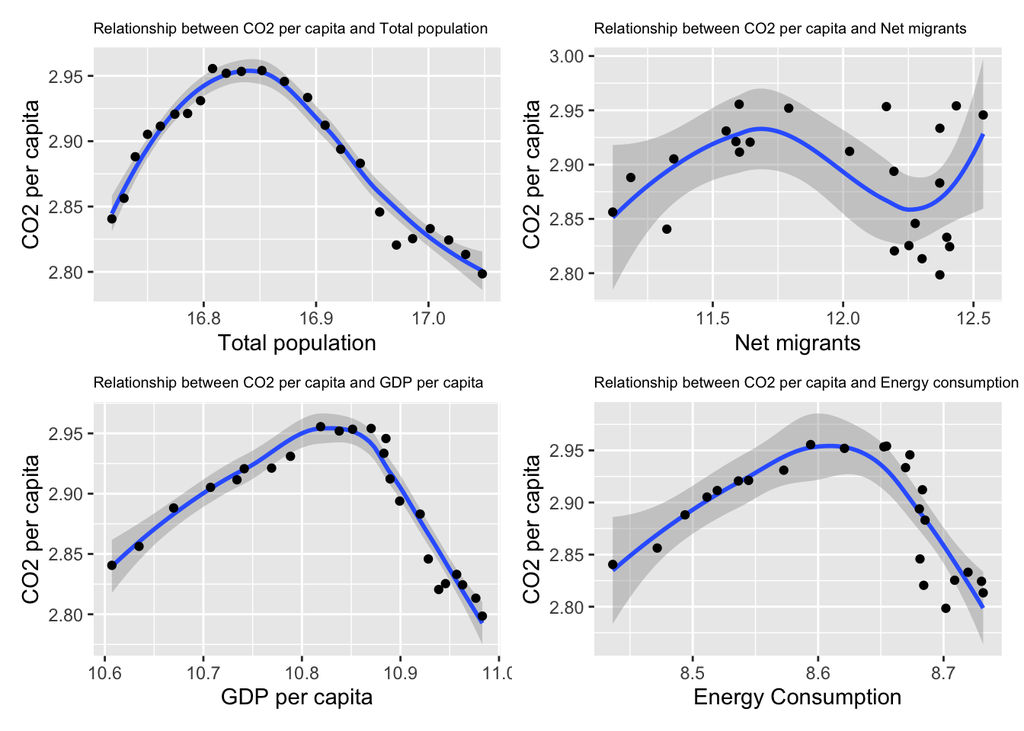

These graphs display the relationship between CO2 per capita and all predictors, revealing that none of the relationships exhibit a linear pattern. As a result, linear regression is not appropriate for this dataset. Consequently, the STIRPAT framework is not suitable for this report since it is based on linear relationship between environment degradation and all predictors. Instead using non-parametric regression would be more relevant for analysing the relationship within this dataset because this regression can capture the non-linear associations between CO2 per capita and the predictors more effectively.

```r
# non-parametric regression without the interactions
fit_1 <- mgcv::gam(co2_capita ~ s(total_pop, bs = 'cr', k = 3) + s(net_migrant, by = total_pop, bs = 'cr', k = 3) + s(gdp_capita, by = total_pop, bs = 'cr', k = 3) + s(energy_consumption, by = total_pop, bs = 'cr', k = 3), data = co2_trans)
```

```r
# non-parametric regression with the interactions
fit_2 <- mgcv::gam(co2_capita ~ s(total_pop, bs = 'cr', k = 3) + s(net_migrant, by = total_pop, bs = 'cr', k = 3) + s(gdp_capita, by = total_pop, bs = 'cr', k = 3) + s(energy_consumption, by = total_pop, bs = 'cr', k = 3) +
                     s(net_migrant, bs = 'cr', k = 3) + s(gdp_capita, bs = 'cr', k = 3) + s(energy_consumption,  bs = 'cr', k = 3), data = co2_trans)
```

```r
# comparing models and find the best model to explain CO2 emission in Australia
anova(fit_1, fit_2, test = "F")
```

```
## Analysis of Deviance Table
##
## Model 1: co2_capita ~ s(total_pop, bs = "cr", k = 3) + s(net_migrant,
##     by = total_pop, bs = "cr", k = 3) + s(gdp_capita, by = total_pop,
##     bs = "cr", k = 3) + s(energy_consumption, by = total_pop,
##     bs = "cr", k = 3)
## Model 2: co2_capita ~ s(total_pop, bs = "cr", k = 3) + s(net_migrant,
##     by = total_pop, bs = "cr", k = 3) + s(gdp_capita, by = total_pop,
##     bs = "cr", k = 3) + s(energy_consumption, by = total_pop,
##     bs = "cr", k = 3) + s(net_migrant, bs = "cr", k = 3) + s(gdp_capita,
##     bs = "cr", k = 3) + s(energy_consumption, bs = "cr", k = 3)
##   Resid. Df Resid. Dev     Df  Deviance     F   Pr(>F)
## 1    17.314 0.00213810
## 2    13.906 0.00046445 3.4072 0.0016737 14.79 9.58e-05 ***
## ---
## Signif. codes:  0 '***' 0.001 '**' 0.01 '*' 0.05 '.' 0.1 ' ' 1
```

As the result, it is significant which means this result rejects the null hypothesis that the non-parametric regression without the interactions is the best model to explain CO2 emission in Australia. Consequently, this result accept the alternative hypothesis that the non-parametric regression with the interactions is the best model to explain CO2 emission in Australia.

```r
summary(fit_2)
```

```
##
## Family: gaussian
## Link function: identity
##
## Formula:
## co2_capita ~ s(total_pop, bs = "cr", k = 3) + s(net_migrant,
##     by = total_pop, bs = "cr", k = 3) + s(gdp_capita, by = total_pop,
##     bs = "cr", k = 3) + s(energy_consumption, by = total_pop,
##     bs = "cr", k = 3) + s(net_migrant, bs = "cr", k = 3) + s(gdp_capita,
##     bs = "cr", k = 3) + s(energy_consumption, bs = "cr", k = 3)
##
## Parametric coefficients:
##              Estimate Std. Error t value Pr(>|t|)
## (Intercept) -0.009748   0.003755  -2.596   0.0212 *
## ---
## Signif. codes:  0 '***' 0.001 '**' 0.01 '*' 0.05 '.' 0.1 ' ' 1
##
## Approximate significance of smooth terms:
##                                   edf Ref.df      F  p-value
## s(total_pop)                    1.967  1.999 32.083 9.90e-06 ***
## s(net_migrant):total_pop        1.332  1.332 14.599 0.012558 *
## s(gdp_capita):total_pop         1.332  1.332 21.296 0.000112 ***
## s(energy_consumption):total_pop 1.371  1.407  5.265 0.054494 .
## s(net_migrant)                  1.000  1.000 10.633 0.005692 **
## s(gdp_capita)                   2.000  2.000 29.970 1.23e-05 ***
## s(energy_consumption)           1.010  1.020  0.357 0.568778
## ---
## Signif. codes:  0 '***' 0.001 '**' 0.01 '*' 0.05 '.' 0.1 ' ' 1
##
## Rank: 15/18
## R-sq.(adj) =  0.988   Deviance explained = 99.3%
## GCV = 5.6999e-05  Scale est. = 3.3212e-05  n = 24
```

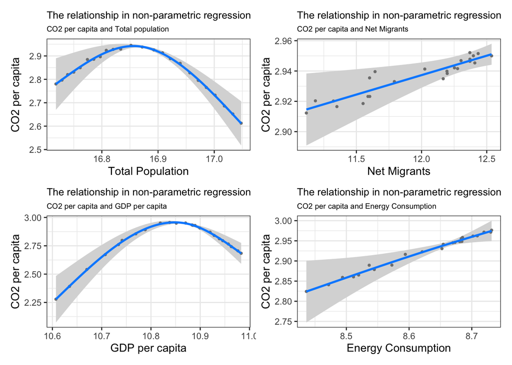

```r
(nl_pop + nl_migrant)/(nl_gdp + nl_ene)
```

```r
fit_3 <- mgcv::gam(co2_capita ~ s(total_pop, bs = 'cr', k = 3) + s(gdp_capita, by = total_pop, bs = 'cr', k = 3) + s(energy_consumption, by = total_pop, bs = 'cr', k = 3) + s(gdp_capita, bs = 'cr', k = 3) + s(energy_consumption,  bs = 'cr', k = 3) + net_migrant:total_pop, data = co2_trans)
```

```r
# comparing models and find the best model to explain CO2 emission in Australia
anova(fit_2, fit_3, test = "F")
```

```
## Analysis of Deviance Table
##
## Model 1: co2_capita ~ s(total_pop, bs = "cr", k = 3) + s(net_migrant,
##     by = total_pop, bs = "cr", k = 3) + s(gdp_capita, by = total_pop,
##     bs = "cr", k = 3) + s(energy_consumption, by = total_pop,
##     bs = "cr", k = 3) + s(net_migrant, bs = "cr", k = 3) + s(gdp_capita,
##     bs = "cr", k = 3) + s(energy_consumption, bs = "cr", k = 3)
## Model 2: co2_capita ~ s(total_pop, bs = "cr", k = 3) + s(gdp_capita, by = total_pop,
##     bs = "cr", k = 3) + s(energy_consumption, by = total_pop,
##     bs = "cr", k = 3) + s(gdp_capita, bs = "cr", k = 3) + s(energy_consumption,
##     bs = "cr", k = 3) + net_migrant:total_pop
##   Resid. Df Resid. Dev       Df    Deviance      F   Pr(>F)
## 1    13.906 0.00046445
## 2    14.066 0.00071126 -0.15967 -0.00024681 46.542 0.001571 **
## ---
## Signif. codes:  0 '***' 0.001 '**' 0.01 '*' 0.05 '.' 0.1 ' ' 1
```

```r
summary(fit_3)
```

```
##
## Family: gaussian
## Link function: identity
##
## Formula:
## co2_capita ~ s(total_pop, bs = "cr", k = 3) + s(gdp_capita, by = total_pop,
##     bs = "cr", k = 3) + s(energy_consumption, by = total_pop,
##     bs = "cr", k = 3) + s(gdp_capita, bs = "cr", k = 3) + s(energy_consumption,
##     bs = "cr", k = 3) + net_migrant:total_pop
##
## Parametric coefficients:
##                         Estimate Std. Error t value Pr(>|t|)
## (Intercept)           -0.0162996  0.0075992  -2.145   0.0495 *
## net_migrant:total_pop  0.0019438  0.0008385   2.318   0.0357 *
## ---
## Signif. codes:  0 '***' 0.001 '**' 0.01 '*' 0.05 '.' 0.1 ' ' 1
##
## Approximate significance of smooth terms:
##                                   edf Ref.df      F  p-value
## s(total_pop)                    1.869  1.979 17.632 0.000163 ***
## s(gdp_capita):total_pop         1.497  1.497 11.360 0.002569 **
## s(energy_consumption):total_pop 2.106  2.230  3.387 0.066564 .
## s(gdp_capita)                   2.000  2.000 14.849 0.000321 ***
## s(energy_consumption)           1.185  1.222  1.199 0.285677
## ---
## Signif. codes:  0 '***' 0.001 '**' 0.01 '*' 0.05 '.' 0.1 ' ' 1
##
## Rank: 12/14
## R-sq.(adj) =  0.982   Deviance explained = 98.9%
## GCV = 8.3046e-05  Scale est. = 4.961e-05  n = 24
```

```
## Conditions used in construction of plot
## gdp_capita: 10.87671
## energy_consumption: 8.662108
## net_migrant: 12.18036
```

```
## Conditions used in construction of plot
## total_pop: 16.86181
## energy_consumption: 8.662108
## net_migrant: 12.18036
```

```
## Conditions used in construction of plot
## total_pop: 16.86181
## gdp_capita: 10.87671
## net_migrant: 12.18036
```

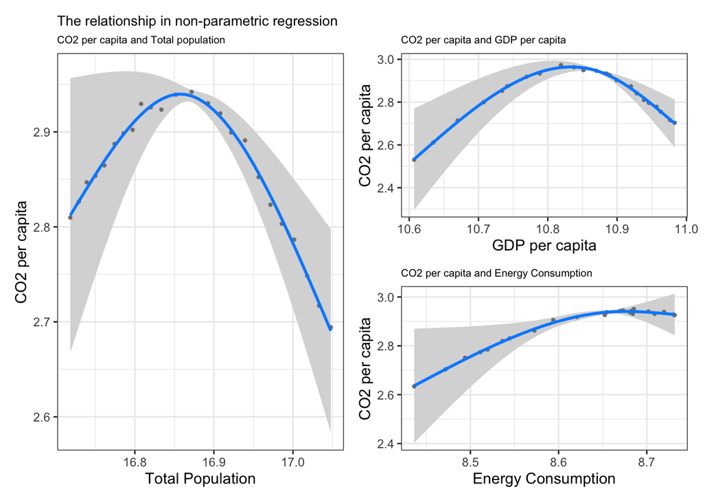

Technology is positive -> doesn’t enough hechnology level and Furthermore, some studies such as Talbi (2017) and Le et al (2020) sounded energy consumption illustrate technology, moreover energy consumption measured by energy intensity, investigated energy intensity positive effects with CO2 emission in short run. (In this case, the meaning of short run is Macroeconomics meaning)